# Modification of asthma treatment efficacy by healthcare access: A reanalysis of AsthmaNet Step-Up Yellow Zone Inhaled Corticosteroids to Prevent Exacerbations (STICS) clinical trial - ScienceDirect

[Sign in](https://www.sciencedirect.com/user/institution/login?targetURL=%2Fscience%2Farticle%2Fpii%2FS0954611124003287)

- [View **PDF**](https://www.sciencedirect.com/science/article/pii/S0954611124003287/pdfft?md5=0f1ceac474c961cce5ff3fc0fc1609cb&pid=1-s2.0-S0954611124003287-main.pdf)

## [Respiratory Medicine](https://www.sciencedirect.com/journal/respiratory-medicine)

[Volume 234](https://www.sciencedirect.com/journal/respiratory-medicine/vol/234/suppl/C), November–December 2024, 107853

# Original Research Modification of asthma treatment efficacy by healthcare access: A reanalysis of AsthmaNet Step-Up Yellow Zone Inhaled Corticosteroids to Prevent Exacerbations (STICS) clinical trial

https://doi.org/10.1016/j.rmed.2024.107853[Get rights and content](https://s100.copyright.com/AppDispatchServlet?publisherName=ELS&contentID=S0954611124003287&orderBeanReset=true)

Under a Creative Commons [license](http://creativecommons.org/licenses/by-nc-nd/4.0/)

open access

## Highlights STICS

- •

  Socioenvironmental factors are key to understanding asthma treatment across populations.
- •

## Abstract

### Background

While randomized controlled trials (RCTs) in asthma management are designed to balance known and unknown variables across treatment groups, including social and environmental co-exposures, it remains important to consider how these co-exposures influence disease progression and treatment outcomes. The importance of considering socio-environmental co-exposures in the context of asthma is twofold: 1) asthma disproportionately affects low-income urban communities, where air pollution and chronic stress are pervasive; and 2) despite the wide range of asthma treatments, inadequate disease control persists.

### Methods

In the present ancillary study of the Step-Up Yellow Zone Inhaled Corticosteroids to Prevent Exacerbations (STICS) RCT, we investigated how socio-environmental factors, such as air pollution exposure and healthcare access, modify the effect of inhaled corticosteroid (ICS) therapy in children with asthma. The original STICS RCT evaluated the efficacy and safety of increasing the dose of inhaled glucocorticoids from a baseline daily low dose to five times the daily dose for 7 days in school-age children with mild -to-moderate persistent asthma who began to have short-term loss of asthma control (Jackson et al., 2018 Mar 8) [1]. Our study adds onto those findings by incorporating residential level particulate matter 2.5 μg/m3 (PM2.5) and geographic health provider shortage areas (HPSA) as potential modifiers.

### Trial registration

[ClinicalTrials.gov](https://clinicaltrials.gov/) ID NCT02066129 https://clinicaltrials.gov/study/NCT02066129.

- [Previous article in issue](https://www.sciencedirect.com/science/article/pii/S0954611124003305)
- [Next article in issue](https://www.sciencedirect.com/science/article/pii/S095461112400297X)

## Keywords

Pediatric asthma

RCT

SDOH

ICS

## 1. Introduction

Randomized controlled trials (RCTs) are regarded as the gold standard for studying causal relationships in medical research, however, their rigorous screening processes and stringent enrollment criteria circumscribe the characteristics of the populations represented within the trial and thus compromise external validity [2]. This is a particularly notable issue in the context of pediatric asthma, as an estimated 50.3 % of children with current asthma have uncontrolled asthma [3] We posit that although RCTs treatment arms are carefully balanced in clinical outcomes at randomization, other co-exposures may be differentially distributed between treatment arms, especially in a relatively small RCT; and that these social and environmental co-exposures may influence treatment efficacy. Therefore transporting results from RCTs to standard clinical care practices necessitates exploring whether internally valid results apply to target populations of interest [4,5].

Given the role of exacerbations on the etiology and economic burden of asthma [6], research attention is focused on treatment efficacy of asthma medications. These include efficacy of inhaled corticosteroids (ICS) to reduce asthma exacerbations while also preventing exposure to systemic steroids. One trial – the Step-up Yellow Zone Inhaled Corticosteroids to Prevent Exacerbations (STICS), implemented by the National Institutes of Health AsthmaNet network, examined the effect of quintupling the dose of inhaled corticosteroids at the early signs of loss of asthma control on asthma exacerbations. The main STICS study found no statistically significant reduction in the rate of severe asthma exacerbations, nor any statistically significant difference in other asthma outcomes, between treatment arms [1]. However, these null findings may result from a combination of differential responses across groups based on differential exposure to socio-environmental features known to impact asthma [[7], [8], [9]]. For instance asthma severity among children varies substantially by socioeconomic status, in part because participants with lower socioeconomic status often reside in areas with greater air pollution, chronic stressors and poorer-quality housing [10]. Additionally, access to healthcare plays a pivotal role in managing asthma effectively. Children residing in communities with limited healthcare access, such as Health Professional Shortage Areas (HPSAs) or Medically Underserved Areas (MUAs), face challenges in obtaining timely and appropriate asthma care. This limitation not only affects the immediate management of asthma exacerbations but also impacts long-term asthma control, potentially altering the efficacy of interventions like ICS.

Exposure to air pollutants, including particulate matter less than 2.5 μg/m<sup>3</sup> in diameter (PM<sub>2.5</sub>), is associated with increased asthma exacerbations [11], increased emergency room visits [12], and decreased lung function [13]. When fine particles deposit in the alveoli, they can trigger lower airway and parenchymal inflammation [14] and impair lung function. The literature on whether treatment with ICS prevents or worsens air pollution-mediated-asthma morbidity is modest to date; however, cigarette smoke, which has parallels with air pollution, has been shown to induce ICS resistance in asthma and thus it is feasible that air pollution may have similar effects [15,16]. Further, a vast body of evidence shows that children who grow up socioeconomically disadvantaged experience greater levels of inflammation and worse asthma symptoms than children from more advantaged backgrounds, leading to potential glucocorticoid resistance [17].

In the present study we hypothesize that air pollution modifies the ICS intervention response in the STICS trial, by decreasing the *time-to-systemic-glucocorticoid-use* among those with higher pollution exposures. We further hypothesize that individuals living in impoverished neighborhoods, characterized by decreased access to medical care (HPSA) or in medically underserved areas (MUAs), will be less responsive to the ICS intervention than children living in areas with greater access to healthcare. To explore these hypotheses, our study has been approved by AsthmaNet as an ancillary study for its novelty and potential to address critical gaps in asthma treatment efficacy research. We leverage geospatial methods, particularly Geographic Information Systems (GIS) based analyses, to allow for the examination of social and environmental exposures that are differentially distributed across trial participants regions and communities. Given the well-documented impacts of air pollution [[7], [8], [9],18,19] and social stressors [[20], [21], [22]] on asthma onset and exacerbations, utilizing GIS-based spatial analysis is particularly relevant to RCTs for asthma.

## 2. Methods

STICS was a population-based clinical trial previously described in detail [1]. Briefly, 254 children aged 5–11 years were randomized in a 1:1 fashion to receive double blinded therapy either at a low dose (1xICS) or high dose (5xICS). Enrollment occurred between 2014 and 2016, and of 444 children initially enrolled, 254 underwent randomization and were followed through March 2017. Upon early signs of loss of asthma control or "yellow zone events," participants randomized to 5xICS were prescribed two inhalations of 220 μg/inhalation of Fluticasone twice daily for seven days, while the group randomized to the low dose group continued with the 1xICS of Fluticasone at 44 μg/inhalation of Fluticasone twice daily for seven days. The current ancillary analysis includes 219 children who completed the STICS trial and whose parent/guardian consented to the use of their residential address for geocoding and spatial analyses.

### 2.1. Outcomes

The trial primary outcome of the trial was the rate of severe asthma exacerbations treated with systemic glucocorticoids (Prednisone) during the blinded study treatment period, prescribed irrespective of residential location. Systemic glucocorticoids use was started after participants reported >6 inhalations of albuterol, a short-acting beta agonist (SABA) in 6 h, ≥12 inhalations of albuterol in 24 h, night awakenings leading to albuterol use during 2 of 3 consecutive nights, or ≥8 inhalations of albuterol during 2 of 3 consecutive days. Secondary outcome measures included time-to-first-asthma exacerbation and treatment failure [defined as 2 asthma exacerbations in 6 months, 3 asthma exacerbations in 1 year, or 6 treated yellow zone episodes]. In this study, we examined the primary and secondary outcomes from the STICS trial.

### 2.2. Geocoding, social, and environmental exposure estimates

Geocoding: The address(es) of each participant's residential location throughout the 52-week trial (4-week run-in and 48-week treatment) were collected by clinical coordinators and geocoded to x,y coordinates using ArcGIS™ (ESRI 2019). A custom-generated address locator using off-line reference data was used to ensure patient confidentiality and maximize positional accuracy of address locations [23]. Addresses were geocoded with a 100 % match rate (n = 219).

Air Pollution Estimates: PM<sub>2.5</sub>, NO<sub>2</sub> and O<sub>3</sub> exposures were estimated for each participant using a spatiotemporal regionalized national universal kriging model [24]. The model combines fine-scale spatial covariates, including roadway information, with daily PM<sub>2.5,</sub> NO<sub>2</sub> and O<sub>3</sub> concentration measurements from EPA AQS, IMPROVE monitoring sites, and researcher-led monitoring campaigns. We estimated two-week average PM<sub>2.5,</sub> NO<sub>2</sub> and O<sub>3</sub> concentrations (in μg/m<sup>3</sup>, ppm and ppb respectively) for all participants based on the centroid of their residential census block. We then computed a simple moving average of the exposure for each participant over the trial follow-up period. For the 14 children whose residence changed during follow up, we computed two-week moving averages corresponding to their combined residential locations. Addresses were stripped from the analytic data set after geocoding and exposure assignments; subsequently, we mapped data positions randomly perturbed to maintain the confidentiality of geographic locations.

Poverty: Census Block Group level data on income-to-poverty ratio were obtained from the 2012–2016 American Community Survey 5-Year summary tables. The income-to-poverty ratio is a percentage comparing income to the federal poverty threshold. We calculated the percentage population with a ratio of income-to-poverty of less than 1 (below 100 % of the poverty threshold) for each Block Group and overlaid STICS patient locations to assign poverty values.

Medically underserved areas and Health Professional Shortage Areas: The US. Health Resources and Services Administration defines Medically Underserved Areas (MUAs) as areas lacking access to primary health care services. An MUA designation depends on the Index of Medical Underservice (IMU) score (1–100), calculated based on the provider-to-population ratio, poverty percentage, population age, and infant mortality rate. Any area with an IMU of 62.0 or below qualifies as an MUA. Health professional shortage area (HPSA) designations are either a geographic area, population group, or health care facility designated by the Health Resources and Services Administration (HRSA) as having a shortage of health professionals. Here we use Primary Care Physician HPSA for census tracts.

Individual and area-level covariates: Adjusting for potential pre-randomization covariates, is considered a good and conservative approach to ancillary RCT analyses [25,26]. Including these pre-randomization covariates reduced the uncertainty associated with outcome measures, thereby increasing the power of the study but did not impact the magnitude of the association between treatment and outcome. Pre-randomization covariates, such as age at enrollment, number of pets, gender, poverty, and race/ethnicity, were selected based on their potential to predict the outcome rather than their influence on treatment assignment, as they are assessed prior to randomization. All co-exposures of interest were median dichotomized to deal with non-parametric statistical approaches and for interpretability.

### 2.3. Statistical methods

The main objective of our analysis was to assess whether socio-environmental variables modified the effect of ICS treatment, at a high versus low dose on the 1) rate of asthma exacerbations, 2) time to asthma exacerbation treated with oral corticosteroids and 3) time to treatment failure.

We conducted this analysis in three steps. First, we replicated the results of the original STICS trial. Original analysis code was provided by the Data Coordinating Center for the NHLBI Asthma Network (AsthmaNet). For this, we modeled the rate of severe asthma exacerbation using a generalized linear model, with a log link function and response following a negative binomial distribution. The model includes recruitment site as a covariate and follow up time as an offset. We summarized time to-event outcomes (outcomes 2 and 3) using Kaplan-Meier curves and compared treatments with the log-rank test [1].

Second, to test whether there was effect modification by socio-environmental variables, we added an interaction term between median dichotomized modifiers and treatment to the generalized linear model. We fitted the stratified Cox Proportional Hazards regression extension to time-to-event outcomes. The significance of interactions between the social/environmental modifier variables and the treatment was assessed using ANOVA Type III tests. We summarized time to event outcomes using Kaplan-Meier curves, and confounders were selected a priori. All tests performed were two-sided, and a P-value of less than 0.05 was considered statistically significant.

Third, we conducted sensitivity analyses to examine results robustness, including removal of outliers (participants with more than 6 exacerbation events over follow-up), not adjusting for potential pre-randomization covariates, requiring a minimum number of days in the study [i.e., at least 100 (n = 201) or at least 180 days (n = 187)], and categorization of effect modifiers in quartiles rather than binary groups. All analyses were performed using SAS software, version 9.4 (SAS Institute), and PM<sub>2.5</sub> exposure estimates were assigned using R version 3.6.3 (R Core Team 2021).

## 3. Results

### 3.1. Descriptive results

Table 1. Analytic sample characteristics at baseline (n = 219).

| Characteristic | 1xICS, N = 107 N | 1xICS, N = 107 N = 107<sup>a</sup> | 5xICS, N = 111 N | 5xICS, N = 111 N = 111 |
| --- | --- | --- | --- | --- |
| Age Group | 107 |  | 111 |  |
| 5–8 yrs |  | 53 (50 %) |  | 57 (51 %) |
| 8–11 yrs |  | 54 (50 %) |  | 54 (49 %) |
| Body Mass Index | 107 | 17.0 (15.6, 19.2) | 111 | 16.8 (15.6, 20.0) |
| Sex | 107 |  | 111 |  |
| Male |  | 66 (62 %) |  | 74 (67 %) |
| Female |  | 41 (38 %) |  | 37 (33 %) |
| Race | 107 |  | 111 |  |
| White |  | 31 (29 %) |  | 46 (41 %) |
| Black |  | 23 (21 %) |  | 22 (20 %) |
| Hispanic |  | 32 (30 %) |  | 32 (29 %) |
| Other |  | 21 (20 %) |  | 11 (9.9 %) |
| Mean NO<sub>2</sub> | 107 | 9.4 (6.1, 13.4) | 111 | 8.6 (5.8, 13.2) |
| Mean PM<sub>2.5</sub> | 107 | 7.49 (6.58, 8.51) | 111 | 7.33 (6.68, 8.40) |
| Mean O<sub>3</sub> | 107 | 25.7 (23.5, 28.9) | 111 | 25.4 (23.5, 28.7) |
| HPSA<sup>b</sup> | 107 |  | 111 |  |
| No |  | 61 (57 %) |  | 69 (62 %) |
| Yes |  | 46 (43 %) |  | 42 (38 %) |
| MUA<sup>c</sup> | 107 |  | 111 |  |
| No |  | 81 (76 %) |  | 78 (70 %) |
| Yes |  | 26 (24 %) |  | 33 (30 %) |

**a**

n (%).

**b**

Geographic Health Provider Shortage Area.

**c**

Medically Underserved Areas.

Table 2. Analytic Sample Characteristics at baseline of full STICS population (n = 254) and ancillary analyses (n = 219).

| Characteristic | Full STICS 1xICS N = 127 | Full STICS 5xICS N = 127 | Ancillary STICS 1xICS N = 107 | Ancillary STICS 5xICS N = 111 |
| --- | --- | --- | --- | --- |
| Age Group |  |  |  |  |
| 5–8 yrs | 63 (50 %) | 63 (50 %) | 53 (50 %) | 57 (51 %) |
| 8–11 yrs | 64 (50 %) | 64 (50 %) | 54 (50 %) | 54 (49 %) |
| Body Mass Index | 17.1 (15.6, 19.4) | 17.1 (15.6, 20.1) | 17.0 (15.6, 19.2) | 16.8 (15.6, 20.0) |
| Sex |  |  |  |  |
| Male | 80 (63 %) | 83 (65 %) | 66 (62 %) | 74 (67 %) |
| Female | 47 (37 %) | 44 (35 %) | 41 (38 %) | 37 (33 %) |
| Race |  |  |  |  |
| White | 37 (29 %) | 49 (39 %) | 31 (29 %) | 46 (41 %) |
| Black | 27 (21 %) | 26 (20 %) | 23 (21 %) | 22 (20 %) |
| Hispanic | 36 (28 %) | 39 (31 %) | 32 (30 %) | 32 (29 %) |
| Other | 27 (21 %) | 13 (10 %) | 21 (20 %) | 11 (9.9 %) |

### 3.2. Rate of asthma exacerbations

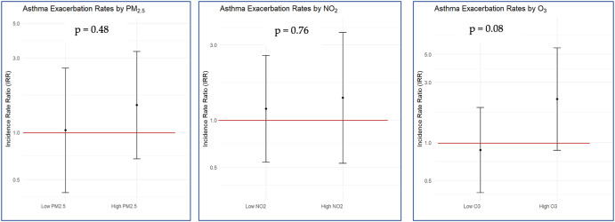

1. [Download: Download high-res image (293KB)](https://ars.els-cdn.com/content/image/1-s2.0-S0954611124003287-gr1_lrg.jpg)
2. [Download: Download full-size image](https://ars.els-cdn.com/content/image/1-s2.0-S0954611124003287-gr1.jpg)

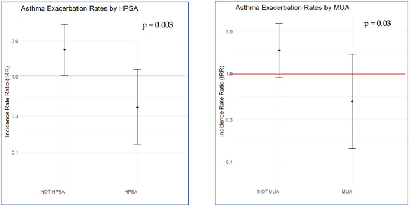

1. [Download: Download high-res image (313KB)](https://ars.els-cdn.com/content/image/1-s2.0-S0954611124003287-gr2_lrg.jpg)
2. [Download: Download full-size image](https://ars.els-cdn.com/content/image/1-s2.0-S0954611124003287-gr2.jpg)

Fig. 2. Associations between treatment with 5xICS (versus 1xICS) and severe asthma exacerbations treated with systemic glucocorticoids by 1) Health provider shortage areas (left) 2) Medically Underserved Areas (right). Incidence Rate Ratios (IRR) and 95 % confidence intervals are presented, and P-values shown are for the interaction term between treatment and each modifier.

### 3.3. Time to prednisone and time to treatment failure

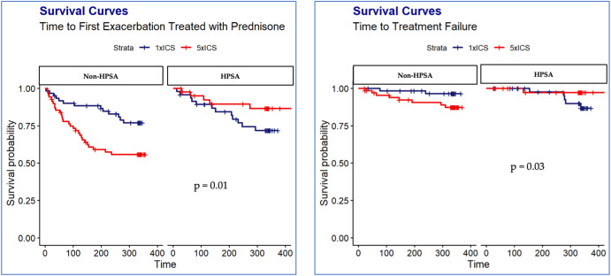

1. [Download: Download high-res image (420KB)](https://ars.els-cdn.com/content/image/1-s2.0-S0954611124003287-gr3_lrg.jpg)
2. [Download: Download full-size image](https://ars.els-cdn.com/content/image/1-s2.0-S0954611124003287-gr3.jpg)

Fig. 3. Time to prednisone use in non-HPSA and HPSA (left) areas (p for interaction = 0.01). Time to treatment failure in non-HPSA and HPSA (right) areas (p for interaction 0.03). Blue line = low dose group (1xICS); red line = high dose group (5xICS). (For interpretation of the references to colour in this figure legend, the reader is referred to the Web version of this article.)

## 4. Discussion

In this study, we aimed to evaluate whether socio-environmental factors, specifically PM<sub>2.5</sub> exposure and neighborhood-level indicators of healthcare access, modify the therapeutic effect of Step-Up Inhaled Corticosteroids. To our knowledge, this is the first *post hoc* analysis to simultaneously investigate the influence of social and environmental factors on ICS treatment efficacy for asthma and to examine variations in efficacy within groups identified by well-known determinants of asthma.

In a systematic review for the Cochrane Database of Systematic Reviews, results indicated that while stepping up ICS doses can improve lung function and reduce exacerbations in the short term, the benefits plateau at moderate doses, with minimal additional gains in control but increased risks of side effects at higher doses [29]. Jackson et al., found similar results in the main analysis of the STICS trial, there were no benefits of the stepped up dose on the time to first asthma exacerbation or time to treatment failure, nor did the 5xICS reduce the symptom scores or albuterol use [1]. This is corroborated by the Global INitiative for Asthma (GINA) guidelines, which advocate for the lowest effective ICS dose to manage asthma [30].

Although, understanding of the complex interactions between social stressors and asthma treatment outcomes continues to advance, the current body of literature exploring how the efficacy of ICS on asthma morbidity may be influenced by social stressors remains limited. The potential mechanisms through which social stressors interact with asthma treatment are multifaceted. For one, chronic stress may alter immune system responses, potentially affecting the inflammatory pathways that ICS aim to control [31]. Moreover, access healthcare constitutes a social determinant of health, and lack of accessible and readily available care can negatively influence asthma disease progression and control [32].

While RCTs increase the internal validity of study findings by employing rigorous screening during recruitment, social and environmental co-exposures that may modify treatment efficacy are often overlooked during this process. The results of this study show that social and environmental co-exposures can modify treatment effects, especially in smaller trials where randomization may not balance unmeasured covariates. Further consideration of variation in treatment efficacy among sub-populations differing in such co-exposures is essential to better understand the results of clinical trials and make them more generalizable to the asthma population.

## 5. Conclusions

Our post-hoc analysis does not change the primary conclusions of the original STICS trial, which found that quintupling the ICS dose at the early signs of loss of asthma control did not provide a significant overall benefit compared to maintaining the regular dose. But rather we found quintupling ICS may lead to worse outcomes in some higher-SES settings. While RCTs increase the internal validity of study findings by employing rigorous screening during recruitment, social and environmental co-exposures that may modify treatment efficacy are often overlooked during this process. The results of this study show that social and environmental co-exposures can modify treatment effects, especially in smaller trials where randomization may not balance unmeasured covariates. Further consideration of variation in treatment efficacy among sub-populations differing in such co-exposures is essential to better understand the results of clinical trials and make them more generalizable to the broader asthma population.

We observed weaker effects of treatment with high doses of inhaled corticosteroids (ICS) in children living in non-HPSA and non-MUAs, compared to HPSAs and MUAs. These findings suggest that participants' social and environmental co-exposures play a role in observed treatment efficacies, and that access to healthcare contributed to the lack of benefit of step-up therapy in the STICS ancillary analyses. Our study highlights the need for future research to consider the potential role of social and environmental factors when designing and analyzing clinical trials for asthma treatment and underscores the importance of individual's unique social and environmental context with respect to their treatment guidelines.

## CRediT authorship contribution statement

**Lizbeth F. Gómez:** Writing – review & editing, Writing – original draft, Visualization, Investigation, Formal analysis, Conceptualization. **Ellen Kinnee:** Writing – review & editing, Supervision, Software, Data curation, Conceptualization. **Joel D. Kaufman:** Writing – review & editing, Data curation. **Michael T. Young:** Writing – review & editing, Resources, Data curation. **Anne M. Fitzpatrick:** Writing – review & editing. **Wanda Phipatanakul:** Writing – review & editing. **David T. Mauger:** Writing – review & editing, Supervision, Data curation, Conceptualization. **Leslie A. McClure:** Writing – review & editing, Supervision. **Usama Bilal:** Writing – review & editing, Supervision. **Fernando Holguin:** Writing – review & editing, Supervision, Conceptualization. **Jane E. Clougherty:** Writing – review & editing, Supervision, Methodology, Funding acquisition, Conceptualization.

## Data sharing

Data collected for this study, including individual participant data and a data dictionary defining each field in the set, will not be made available to others. Deidentified participant data, data dictionary, study protocol, statistical analysis plan, and informed consent form can be made available upon request. Access to the data will be granted after approval of a proposal and the signing of a data access agreement. Additional restrictions may apply depending on the proposed analysis and intended use of the data.

## Contributions

The first draft of the manuscript was written by Lizbeth Gómez. GIS methods were written by Ellen Kinnee, and clinical relevance discussion was written by Fernando Holguin, Jane E. Clougherty, Usama Bilal and Leslie McClure completed all copy editing for this manuscript. All other authors contributed to the writing and editing of the final version of the manuscript.

## Funding

This work was funded by the NIH National Heart, Lung, and Blood Institute(NHLBI) (1R01HL114536–01: Validating GIS-based methods to address spatial uncertainty in clinical trials, to JEC and FH). The AsthmaNet trials were funded by NIH grants HL098302, HL098096, HL098075, HL098090, HL098177, HL098098, HL098107, HL098112, 098,103, and HL098115.

## Declaration of competing interest

The authors declare that they have no known competing financial interests or personal relationships that could have appeared to influence the work reported in this paper.

## Appendix A. Supplementary data

The following is the Supplementary data to this article.[Download: Download Word document (37MB)](https://ars.els-cdn.com/content/image/1-s2.0-S0954611124003287-mmc1.docx)

Multimedia component 1.

## References

1. [1]

   D.J. Jackson, L.B. Bacharier, D.T. Mauger, S. Boehmer, A. Beigelman, J.F. Chmiel, *et al.*

   Quintupling inhaled glucocorticoids to prevent childhood asthma exacerbations

   N. Engl. J. Med., 378 (10) (2018 Mar 8), pp. 891-901

   [View at publisher](https://doi.org/10.1056/nejmoa1710988)[Crossref](https://doi.org/10.1056/nejmoa1710988)[View in Scopus](https://www.scopus.com/inward/record.url?eid=2-s2.0-85043585719&partnerID=10&rel=R3.0.0)Google Scholar
2. [2]

   J. Travers, S. Marsh, M. Williams, M. Weatherall, B. Caldwell, P. Shirtcliffe, *et al.*

   External validity of randomised controlled trials in asthma: to whom do the results of the trials apply?

   Thorax, 62 (3) (2007 Mar), pp. 219-223

   [View at publisher](https://doi.org/10.1136/thx.2006.066837)[Crossref](https://doi.org/10.1136/thx.2006.066837)Google Scholar
3. [3]

   S. Binney, W.D. Flanders, K. Sircar, O. Idubor

   Trends in US Pediatric Asthma Hospitalizations, by Race and Ethnicity, 2012–2020

   Prev Chronic Dis, 21 (2024), p. 24004

   Google Scholar
4. [4]

   D. Westreich, J.K. Edwards, C.R. Lesko, E. Stuart, S.R. Cole

   Transportability of trial results using inverse odds of sampling weights

   Am. J. Epidemiol., 186 (8) (2017 Oct 15), pp. 1010-1014

   View at publisher

   [Crossref](https://doi.org/10.1093/aje/kwx164)[View in Scopus](https://www.scopus.com/inward/record.url?eid=2-s2.0-85031914762&partnerID=10&rel=R3.0.0)Google Scholar
5. [5]

   P.N. Zivich, J.K. Edwards, E.T. Lofgren, S.R. Cole, B.E. Shook-Sa, J. Lessler

   Transportability without positivity: a synthesis of statistical and simulation modeling

   Epidemiology, 35 (1) (2024 Jan), p. 23

   [View at publisher](https://doi.org/10.1097/ede.0000000000001677)[Crossref](https://doi.org/10.1097/ede.0000000000001677)[View in Scopus](https://www.scopus.com/inward/record.url?eid=2-s2.0-85178495709&partnerID=10&rel=R3.0.0)Google Scholar
6. [6]

   P.W. Sullivan, V. Ghushchyan, P. Navaratnam, H.S. Friedman, A. Kavati, B. Ortiz, *et al.*

   The national cost of asthma among school-aged children in the United States

   Ann. Allergy Asthma Immunol., 119 (3) (2017 Sep 1), pp. 246-252.e1

   [View PDF](https://www.sciencedirect.com/science/article/pii/S1081120617305422/pdfft?md5=1dbcc43a088a1161c9c190b9365694c5&pid=1-s2.0-S1081120617305422-main.pdf)[View article](https://www.sciencedirect.com/science/article/pii/S1081120617305422)[View in Scopus](https://www.scopus.com/inward/record.url?eid=2-s2.0-85029667742&partnerID=10&rel=R3.0.0)Google Scholar
7. [7]

   H. Khreis, M. Cirach, N. Mueller, K. de Hoogh, G. Hoek, M.J. Nieuwenhuijsen, D. Rojas-Rueda

   Outdoor air pollution and the burden of childhood asthma across Europe

   Eur. Respir. J., 54 (4) (2019 Oct 31)

   Google Scholar
8. [8]

   M. Brauer, G. Hoek, H.A. Smit, JC de Jongste, J. Gerritsen, D.S. Postma, *et al.*

   Air pollution and development of asthma, allergy and infections in a birth cohort

   Eur. Respir. J., 29 (5) (2007 May 1), pp. 879-888

   [View at publisher](https://doi.org/10.1183/09031936.00083406)[Crossref](https://doi.org/10.1183/09031936.00083406)[View in Scopus](https://www.scopus.com/inward/record.url?eid=2-s2.0-34248212154&partnerID=10&rel=R3.0.0)Google Scholar
9. [9]

   M. Guarnieri, J.R. Balmes

   Outdoor air pollution and asthma

   Lancet, 383 (9928) (2014 May 3), pp. 1581-1592

   [View PDF](https://www.sciencedirect.com/science/article/pii/S0140673614606176/pdfft?md5=7b36cfee430a8894b79538abbcc0978e&pid=1-s2.0-S0140673614606176-main.pdf)[View article](https://www.sciencedirect.com/science/article/pii/S0140673614606176)[View in Scopus](https://www.scopus.com/inward/record.url?eid=2-s2.0-84900012988&partnerID=10&rel=R3.0.0)Google Scholar
10. [10]

    T.F. Carr, E. Bleecker

    Asthma heterogeneity and severity

    World Allergy Organ J, 9 (1) (2016 Nov 29), p. 41

    [View PDF](https://www.sciencedirect.com/science/article/pii/S1939455119301966/pdfft?md5=a25b8c72751c119409c4a21e799772c6&pid=1-s2.0-S1939455119301966-main.pdf)[View article](https://www.sciencedirect.com/science/article/pii/S1939455119301966)[View in Scopus](https://www.scopus.com/inward/record.url?eid=2-s2.0-84999106786&partnerID=10&rel=R3.0.0)Google Scholar
11. [11]

    N. Bouazza, F. Foissac, S. Urien, R. Guedj, R. Carbajal, J.M. Tréluyer, *et al.*

    Fine particulate pollution and asthma exacerbations

    Arch. Dis. Child., 103 (9) (2018 Sep), pp. 828-831

    [View at publisher](https://doi.org/10.1136/archdischild-2017-312826)[Crossref](https://doi.org/10.1136/archdischild-2017-312826)[View in Scopus](https://www.scopus.com/inward/record.url?eid=2-s2.0-85049230197&partnerID=10&rel=R3.0.0)Google Scholar
12. [12]

    L.H. Tecer, O. Alagha, F. Karaca, G. Tuncel, N. Eldes

    Particulate matter (PM2.5, PM10-2.5, and PM10) and children's hospital admissions for asthma and respiratory diseases: a bidirectional case-crossover study

    J. Toxicol. Environ. Health, Part A, 71 (8) (2008 Mar 12), pp. 512-520

    [View at publisher](https://doi.org/10.1080/15287390801907459)[Crossref](https://doi.org/10.1080/15287390801907459)[View in Scopus](https://www.scopus.com/inward/record.url?eid=2-s2.0-40749134213&partnerID=10&rel=R3.0.0)Google Scholar
13. [13]

    Tjoa Thomas Delfino, Dan Gillen, Michael T. Kleinman, Sioutas Constantinos, Dan Cooper

    Personal and ambient air pollution exposures and lung function decrements in children with asthma

    Environ. Health Perspect., 116 (4) (2008 Apr 1), pp. 550-558

    [View at publisher](https://doi.org/10.1289/ehp.10911)[Crossref](https://doi.org/10.1289/ehp.10911)[View in Scopus](https://www.scopus.com/inward/record.url?eid=2-s2.0-45749119511&partnerID=10&rel=R3.0.0)Google Scholar
14. [14]

    X. Xu, J. Zhang, X. Yang, Y. Zhang, Z. Chen

    The role and potential pathogenic mechanism of particulate matter in childhood asthma: a review and perspective

    Journal of Immunology Research, 2020 (2020 Jan 17), Article e8254909

    Google Scholar
15. [15]

    P.J. Barnes

    Corticosteroid resistance in patients with asthma and chronic obstructive pulmonary disease

    J. Allergy Clin. Immunol., 131 (3) (2013 Mar 1), pp. 636-645

    [View PDF](https://www.sciencedirect.com/science/article/pii/S0091674912035646/pdfft?md5=da1abfb09de3492e60e1afa81c080ae2&pid=1-s2.0-S0091674912035646-main.pdf)[View article](https://www.sciencedirect.com/science/article/pii/S0091674912035646)[View in Scopus](https://www.scopus.com/inward/record.url?eid=2-s2.0-84875225940&partnerID=10&rel=R3.0.0)Google Scholar
16. [16]

    C.F. Rider, C. Carlsten

    Air pollution and resistance to inhaled glucocorticoids: evidence, mechanisms and gaps to fill

    Pharmacol. Ther., 194 (2019 Feb), pp. 1-21

    [View PDF](https://www.sciencedirect.com/science/article/pii/S0163725818301438/pdfft?md5=948c8c3d5694308da8de2e2352e0f438&pid=1-s2.0-S0163725818301438-main.pdf)[View article](https://www.sciencedirect.com/science/article/pii/S0163725818301438)[View in Scopus](https://www.scopus.com/inward/record.url?eid=2-s2.0-85053344699&partnerID=10&rel=R3.0.0)Google Scholar
17. [17]

    Y. Jiang, A.K. Farrell, E.T. Tobin, H. Mair-Meijers, D.E. Wildman, F. Luca, *et al.*

    Socioeconomic status, financial stress, and glucocorticoid resistance among youth with asthma: testing the moderation effects of maternal involvement and warmth

    Brain Behav. Immun., 96 (2021 Aug), pp. 92-99

    [View PDF](https://www.sciencedirect.com/science/article/pii/S0889159121001951/pdfft?md5=9f510cf089fd7901e975e1345ca0616d&pid=1-s2.0-S0889159121001951-main.pdf)[View article](https://www.sciencedirect.com/science/article/pii/S0889159121001951)[View in Scopus](https://www.scopus.com/inward/record.url?eid=2-s2.0-85107438732&partnerID=10&rel=R3.0.0)Google Scholar
18. [18]

    B. Ostro, M. Lipsett, J. Mann, H. Braxton-Owens, White and M

    Air pollution and exacerbation of asthma in african-American children in los angeles

    Epidemiology, 12 (2) (2001 Mar), pp. 200-208

    [View in Scopus](https://www.scopus.com/inward/record.url?eid=2-s2.0-0035113383&partnerID=10&rel=R3.0.0)Google Scholar
19. [19]

    Nina Annika Clark, Paul A. Demers, Catherine J. Karr, Koehoorn Mieke, Lencar Cornel, Tamburic Lillian, *et al.*

    Effect of early life exposure to air pollution on development of childhood asthma

    Environ. Health Perspect., 118 (2) (2010 Feb 1), pp. 284-290

    [View at publisher](https://doi.org/10.1289/ehp.0900916)[Crossref](https://doi.org/10.1289/ehp.0900916)[View in Scopus](https://www.scopus.com/inward/record.url?eid=2-s2.0-77149148731&partnerID=10&rel=R3.0.0)Google Scholar
20. [20]

    A.A. Cruz, E.D. Bateman, J. Bousquet

    The social determinants of asthma

    Eur. Respir. J., 35 (2) (2010 Feb 1), pp. 239-242

    [View at publisher](https://doi.org/10.1183/09031936.00070309)[Crossref](https://doi.org/10.1183/09031936.00070309)[View in Scopus](https://www.scopus.com/inward/record.url?eid=2-s2.0-76149142811&partnerID=10&rel=R3.0.0)Google Scholar
21. [21]

    C.A. Keet, M.C. McCormack, C.E. Pollack, R.D. Peng, E. McGowan, E.C. Matsui

    Neighborhood poverty, urban residence, race/ethnicity, and asthma: rethinking the inner-city asthma epidemic

    J. Allergy Clin. Immunol., 135 (3) (2015 Mar 1), pp. 655-662

    [View PDF](https://www.sciencedirect.com/science/article/pii/S0091674914016765/pdfft?md5=4e26236afed53069d54e7755add8b086&pid=1-s2.0-S0091674914016765-main.pdf)[View article](https://www.sciencedirect.com/science/article/pii/S0091674914016765)[View in Scopus](https://www.scopus.com/inward/record.url?eid=2-s2.0-84924532440&partnerID=10&rel=R3.0.0)Google Scholar
22. [22]

    C. Andrew Aligne, P. Auinger, R.S. Byrd, M. Weitzman

    Risk factors for pediatric asthma

    Am. J. Respir. Crit. Care Med., 162 (3) (2000 Sep 1), pp. 873-877

    [View at publisher](https://doi.org/10.1164/ajrccm.162.3.9908085)[Crossref](https://doi.org/10.1164/ajrccm.162.3.9908085)Google Scholar
23. [23]

    E.J. Kinnee, S. Tripathy, L. Schinasi, J.L.C. Shmool, P.E. Sheffield, F. Holguin, *et al.*

    Geocoding error, spatial uncertainty, and implications for exposure assessment and environmental Epidemiology

    Int. J. Environ. Res. Publ. Health, 17 (16) (2020 Aug 12), Article E5845

    Google Scholar
24. [24]

    K. Kirwa, A.A. Szpiro, L. Sheppard, P.D. Sampson, M. Wang, J.P. Keller, *et al.*

    Fine-scale air pollution models for epidemiologic research: insights from approaches developed in the multi-ethnic study of atherosclerosis and air pollution (MESA air)

    Curr Envir Health Rpt, 8 (2) (2021 Jun 1), pp. 113-126

    [View at publisher](https://doi.org/10.1007/s40572-021-00310-y)[Crossref](https://doi.org/10.1007/s40572-021-00310-y)[View in Scopus](https://www.scopus.com/inward/record.url?eid=2-s2.0-85107204915&partnerID=10&rel=R3.0.0)Google Scholar
25. [25]

    C.V. Ananth, J.A. Lavery

    Biases in secondary analyses of randomised trials: recognition, correction, and implications

    BJOG An Int. J. Obstet. Gynaecol., 123 (7) (2016), pp. 1056-1059

    View at publisher

    [Crossref](https://doi.org/10.1111/1471-0528.13732)[View in Scopus](https://www.scopus.com/inward/record.url?eid=2-s2.0-84978419955&partnerID=10&rel=R3.0.0)Google Scholar
26. [26]

    M.J. Holmberg, L.W. Andersen

    Adjustment for baseline characteristics in randomized clinical trials

    JAMA, 328 (21) (2022 Dec 6), pp. 2155-2156

    View at publisher

    [Crossref](https://doi.org/10.1001/jama.2022.21506)Google Scholar
27. [27]

    J.M. Bruzzese, S. Kingston, K.A. Falletta, E. Bruzelius, L. Poghosyan

    Individual and neighborhood factors associated with undiagnosed asthma in a large cohort of urban adolescents

    J. Urban Health, 96 (2) (2019 Apr), pp. 252-261

    [View at publisher](https://doi.org/10.1007/s11524-018-00340-2)[Crossref](https://doi.org/10.1007/s11524-018-00340-2)[View in Scopus](https://www.scopus.com/inward/record.url?eid=2-s2.0-85060165903&partnerID=10&rel=R3.0.0)Google Scholar
28. [28]

    I.D. Pavord, T.N. Tran, R.C. Jones, J. Nuevo, M. van den Berge, G.G. Brusselle, AN. Menzies-Gow, D. Skinner, V. Carter

    Effect of stepping up to high-dose inhaled corticosteroids in patients with asthma: UK Database study

    J. Allergy Clin. Immunol. Pract., 11 (2) (2023), pp. 532-543

    [View PDF](https://www.sciencedirect.com/science/article/pii/S2213219822011436/pdfft?md5=bcf3e1a45231e2c78917f4bea50c93e4&pid=1-s2.0-S2213219822011436-main.pdf)[View article](https://www.sciencedirect.com/science/article/pii/S2213219822011436)[View in Scopus](https://www.scopus.com/inward/record.url?eid=2-s2.0-85143284938&partnerID=10&rel=R3.0.0)Google Scholar
29. [29]

    D.J. Evans, K.M. Kew, D.E. Anderson, A.C. Boyter

    Long‐acting muscarinic antagonists (LAMA) added to inhaled corticosteroids (ICS) versus higher dose ICS for adults with asthma

    Cochrane Database Syst. Rev., 2015 (7) (2015 Jul 21), Article CD011437

    [View in Scopus](https://www.scopus.com/inward/record.url?eid=2-s2.0-84955280277&partnerID=10&rel=R3.0.0)Google Scholar
30. [30]

    D.M. Sobieraj, E.R. Weeda, E. Nguyen, C.I. Coleman, C.M. White, S.C. Lazarus, *et al.*

    Association of inhaled corticosteroids and long-acting β-agonists as controller and quick relief therapy with exacerbations and symptom control in persistent asthma: a systematic review and meta-analysis

    JAMA, 319 (14) (2018 Apr 10), pp. 1485-1496

    [View in Scopus](https://www.scopus.com/inward/record.url?eid=2-s2.0-85045181598&partnerID=10&rel=R3.0.0)Google Scholar
31. [31]

    A. Haczku, R.A. Panettieri

    Social stress and asthma: the role of corticosteroid insensitivity

    J. Allergy Clin. Immunol., 125 (3) (2010 Mar), pp. 550-558

    [View PDF](https://www.sciencedirect.com/science/article/pii/S0091674909017199/pdfft?md5=5ffe241b2875d69aaf6ded69406fb622&pid=1-s2.0-S0091674909017199-main.pdf)[View article](https://www.sciencedirect.com/science/article/pii/S0091674909017199)[View in Scopus](https://www.scopus.com/inward/record.url?eid=2-s2.0-77649270933&partnerID=10&rel=R3.0.0)Google Scholar
32. [32]

    T. Grant, E. Croce, E.C. Matsui

    Asthma and the social determinants of health

    Ann. Allergy Asthma Immunol., 128 (1) (2022 Jan 1), pp. 5-11

    [View PDF](https://www.sciencedirect.com/science/article/pii/S1081120621011327/pdfft?md5=93a5ca8ccdee2b714f3267f8ea43a4fc&pid=1-s2.0-S1081120621011327-main.pdf)[View article](https://www.sciencedirect.com/science/article/pii/S1081120621011327)[View in Scopus](https://www.scopus.com/inward/record.url?eid=2-s2.0-85119199606&partnerID=10&rel=R3.0.0)Google Scholar

## Cited by (0)

© 2024 The Authors. Published by Elsevier Ltd.